# Introduction to Image Processing

∿Numerical Tours

# Introduction to Image Processing

Explore how arrays become images, how convolution removes fine detail, and how derivatives reveal boundaries. Compare spatial operations with their Fourier-domain counterparts to connect the formulas with visible changes in an image.

## Run this tour

Run the cells in order with a Python 3 kernel. The first cell locates the companion data and toolbox and installs missing dependencies when needed. All worked examples include their implementation directly in this notebook. Random seeds make comparisons reproducible; you can change them to explore other samples.

```python
# Locate the companion toolbox locally, or fetch it for a standalone/Colab copy.
from pathlib import Path
import importlib.util
import os
import subprocess
import sys

working = Path.cwd()
candidates = [working, working / "python", working.parent / "python"]
python_dir = next((p for p in candidates if (p / "nt_toolbox").is_dir()), None)
if python_dir is None:
    checkout = working / "numerical-tours-support"
    if not checkout.exists():
        subprocess.run(
            [
                "git",
                "clone",
                "--depth",
                "1",
                "--branch",
                "master",
                "https://github.com/gpeyre/numerical-tours.git",
                str(checkout),
            ],
            check=True,
        )
    python_dir = checkout / "python"
os.chdir(python_dir)
if str(python_dir) not in sys.path:
    sys.path.insert(0, str(python_dir))
requirements = python_dir / "requirements.txt"
if any(
    importlib.util.find_spec(name) is None
    for name in [
        "numpy",
        "scipy",
        "matplotlib",
        "skimage",
        "sklearn",
        "pywt",
        "ipywidgets",
        "cvxpy",
        "skfmm",
        "autograd",
        "progressbar",
        "celer",
    ]
):
    subprocess.run(
        [sys.executable, "-m", "pip", "install", "-r", str(requirements)], check=True
    )

import numpy as np
import matplotlib.pyplot as plt

np.random.seed(0)
plt.rcParams.update(
    {
        "figure.figsize": (8, 4),
        "figure.dpi": 100,
        "axes.spines.top": False,
        "axes.spines.right": False,
        "font.size": 11,
        "image.cmap": "gray",
    }
)
%matplotlib inline
```

This numerical tour explores some basic image processing tasks.

$\newcommand{\dotp}[2]{\langle #1, #2 \rangle}$ $\newcommand{\enscond}[2]{\lbrace #1, #2 \rbrace}$ $\newcommand{\pd}[2]{ \frac{ \partial #1}{\partial #2} }$ $\newcommand{\umin}[1]{\underset{#1}{\min}\;}$ $\newcommand{\umax}[1]{\underset{#1}{\max}\;}$ $\newcommand{\uargmin}[1]{\underset{#1}{argmin}\;}$ $\newcommand{\norm}[1]{\|#1\|}$ $\newcommand{\abs}[1]{\left|#1\right|}$ $\newcommand{\choice}[1]{ \left\{ \begin{array}{l} #1 \end{array} \right. }$ $\newcommand{\pa}[1]{\left(#1\right)}$ $\newcommand{\diag}[1]{{diag}\left( #1 \right)}$ $\newcommand{\qandq}{\quad\text{and}\quad}$ $\newcommand{\qwhereq}{\quad\text{where}\quad}$ $\newcommand{\qifq}{ \quad \text{if} \quad }$ $\newcommand{\qarrq}{ \quad \Longrightarrow \quad }$ $\newcommand{\ZZ}{\mathbb{Z}}$ $\newcommand{\CC}{\mathbb{C}}$ $\newcommand{\RR}{\mathbb{R}}$ $\newcommand{\EE}{\mathbb{E}}$ $\newcommand{\Zz}{\mathcal{Z}}$ $\newcommand{\Ww}{\mathcal{W}}$ $\newcommand{\Vv}{\mathcal{V}}$ $\newcommand{\Nn}{\mathcal{N}}$ $\newcommand{\NN}{\mathcal{N}}$ $\newcommand{\Hh}{\mathcal{H}}$ $\newcommand{\Bb}{\mathcal{B}}$ $\newcommand{\Ee}{\mathcal{E}}$ $\newcommand{\Cc}{\mathcal{C}}$ $\newcommand{\Gg}{\mathcal{G}}$ $\newcommand{\Ss}{\mathcal{S}}$ $\newcommand{\Pp}{\mathcal{P}}$ $\newcommand{\Ff}{\mathcal{F}}$ $\newcommand{\Xx}{\mathcal{X}}$ $\newcommand{\Mm}{\mathcal{M}}$ $\newcommand{\Ii}{\mathcal{I}}$ $\newcommand{\Dd}{\mathcal{D}}$ $\newcommand{\Ll}{\mathcal{L}}$ $\newcommand{\Tt}{\mathcal{T}}$ $\newcommand{\si}{\sigma}$ $\newcommand{\al}{\alpha}$ $\newcommand{\la}{\lambda}$ $\newcommand{\ga}{\gamma}$ $\newcommand{\Ga}{\Gamma}$ $\newcommand{\La}{\Lambda}$ $\newcommand{\Si}{\Sigma}$ $\newcommand{\be}{\beta}$ $\newcommand{\de}{\delta}$ $\newcommand{\De}{\Delta}$ $\newcommand{\phi}{\varphi}$ $\newcommand{\th}{\theta}$ $\newcommand{\om}{\omega}$ $\newcommand{\Om}{\Omega}$

```python
from nt_toolbox.general import np, transform
from nt_toolbox.signal import grad, imageplot, load_image, np, transform
import numpy as np
import matplotlib.pyplot as plt
from numpy import (
    abs,
    arange,
    array,
    concatenate,
    cos,
    exp,
    linspace,
    log,
    matrix,
    number,
    pi,
    real,
    sum,
    transpose,
)
from matplotlib.pyplot import clf, matplotlib, np
from numpy.fft import fft2, fftshift, ifft2

%matplotlib inline
```

## Image Loading and Displaying

Several functions are implemented to load and display images.

First we load an image.

path to the images

```python
name = "nt_toolbox/data/hibiscus.bmp"
n = 256
M = load_image(name, n)
```

We can display it. It is possible to zoom on it, extract pixels, etc.

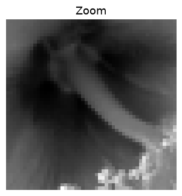

```python
m = int(n / 2)
imageplot(M[m - 25 : m + 25, m - 25 : m + 25], "Zoom", [1, 2, 2])
```

## Image Modification

An image is a 2D array, that can be modified as a matrix.

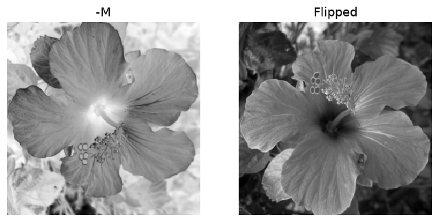

```python
imageplot(-M, "-M", [1, 2, 1])
imageplot(M[::-1, :], "Flipped", [1, 2, 2])
```

Blurring is achieved by computing a convolution with a kernel.

Compute the low pass Gaussian kernel. Warning, the indexes needs to be modulo $n$ in order to use FFTs.

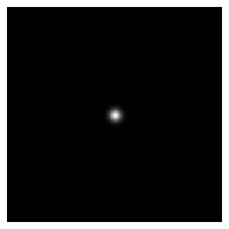

```python
sigma = 5
t = concatenate((arange(0, n / 2 + 1), arange(-n / 2, -1)))
[Y, X] = np.meshgrid(t, t)
h = exp(-(X**2 + Y**2) / (2.0 * float(sigma) ** 2))
h = h / sum(h)
imageplot(fftshift(h))
```

Compute the periodic convolution ussing FFTs

```python
Mh = real(ifft2(fft2(M) * fft2(h)))
```

Display

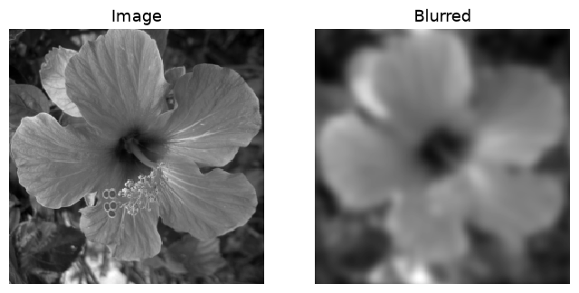

```python
imageplot(M, "Image", [1, 2, 1])
imageplot(Mh, "Blurred", [1, 2, 2])
```

Several differential and convolution operators are implemented.

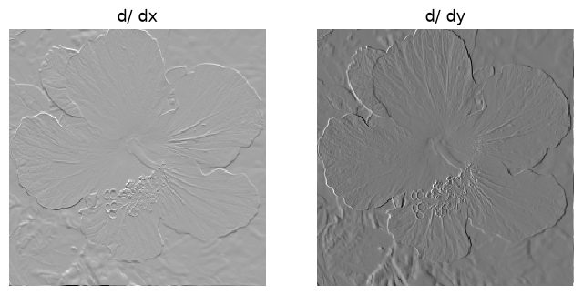

```python
G = grad(M)
imageplot(G[:, :, 0], "d/ dx", [1, 2, 1])
imageplot(G[:, :, 1], "d/ dy", [1, 2, 2])
```

## Fourier Transform

The 2D Fourier transform can be used to perform low pass approximation and interpolation (by zero padding).

Compute and display the Fourier transform (display over a log scale). The function fftshift is useful to put the 0 low frequency in the middle. After fftshift, the zero frequency is located at position $(n/2+1,n/2+1)$.

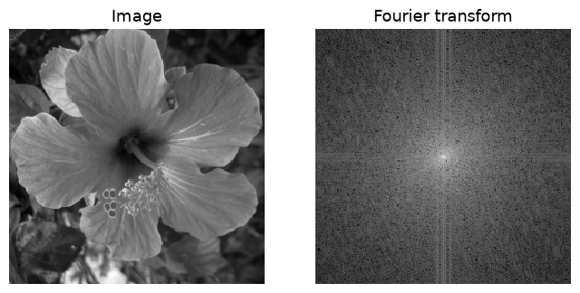

```python
Mf = fft2(M)
Lf = fftshift(log(abs(Mf) + 1e-1))
imageplot(M, "Image", [1, 2, 1])
imageplot(Lf, "Fourier transform", [1, 2, 2])
```

**Worked example 1:** To avoid boundary artifacts and estimate really the frequency content of the image (and not of the artifacts!), one needs to multiply M by a smooth windowing function h and compute fft2(M*h). Use a sine windowing function. Can you interpret the resulting filter ?

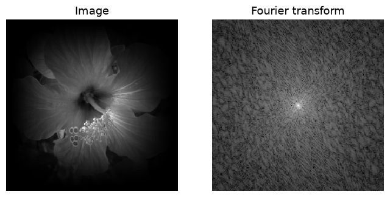

```python
# compute kernel h
t = linspace(-pi, pi, n)
h0 = matrix((cos(t) + 1) / 2)
h = array(transpose(h0) * h0)
# compute FFT
Mf = fft2(M * h)
Lf = fftshift(log(abs(Mf) + 1e-1))
# display
clf
imageplot(M * h, "Image", [1, 2, 1])
imageplot(Lf, "Fourier transform", [1, 2, 2])
```

**Worked example 2:** Perform low pass filtering by removing the high frequencies of the spectrum. What do you oberve ?

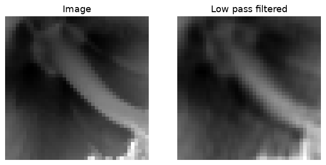

```python
k = round(0.8 * n)
k = round(k / 2) * 2  # even number
Mf = fft2(M)
r = int(k / 2)
Mf[m - r + 2 : m + r, m - r + 2 : m + r] = 0
Mh = real(ifft2(Mf))
# display
clf
imageplot(M[m - 20 : m + 20, m - 20 : m + 20], "Image", [1, 2, 1])
imageplot(Mh[m - 20 : m + 20, m - 20 : m + 20], "Low pass filtered", [1, 2, 2])
```

## References and further reading

- Stéphane Mallat. [A Wavelet Tour of Signal Processing: The Sparse Way](https://www.di.ens.fr/~mallat/biblio.html). 2009, 3rd ed., Academic Press. Multiresolution analysis, sparse approximation, and wavelet algorithms.
- Gabriel Peyré. [Advanced Signal, Image and Surface Processing](https://www.numerical-tours.com/book/AdvancedSignalProcessing.pdf). 2010, course notes. A mathematical companion to the Numerical Tours.
- Stéfan van der Walt et al.. [scikit-image: image processing in Python](https://doi.org/10.7717/peerj.453). 2014, PeerJ 2:e453. Reproducible image processing and image measurements in Python.
- Pauli Virtanen et al.. [SciPy 1.0: Fundamental Algorithms for Scientific Computing in Python](https://doi.org/10.1038/s41592-019-0686-2). 2020, Nature Methods 17, 261–272. The numerical routines used for transforms, interpolation, and optimization.
- Gilbert Strang. [Linear Algebra and Learning from Data](https://math.mit.edu/~gs/learningfromdata/). 2019, Wellesley-Cambridge Press. Matrix factorizations, least squares, and low-rank representations.